# Лабораторная работа №2

Операционные системы

Лебеденко Е.В.

Российский университет дружбы народов, Москва, Россия

24 февраля 2026

# Информация

## Докладчик

- Лебеденко Елена Викторовна
- Студент НКАбд-04-25
- Российский университет дружбы народов
- 1032253535@rudn.ru

# Цель работы

Изучить идеологию и применение средств контроля версий, а также освоить умения по работе с git.

# Задание

- Создать базовую конфигурацию для работы с git.
- Создать ключ SSH.
- Создать ключ PGP.
- Настроить подписи git.
- Зарегистрироваться на Github.
- Создать локальный каталог для выполнения заданий по предмету.

# Теоретическое введение

Системы контроля версий (Version Control System, VCS) применяются при работе нескольких человек над одним проектом. Обычно основное дерево проекта хранится в локальном или удалённом репозитории, к которому настроен доступ для участников проекта. При внесении изменений в содержание проекта система контроля версий позволяет их фиксировать, совмещать изменения, произведённые разными участниками проекта, производить откат к любой более ранней версии проекта, если это требуется.

# Выполнение лабораторной работы

Устанавливаю git и gh

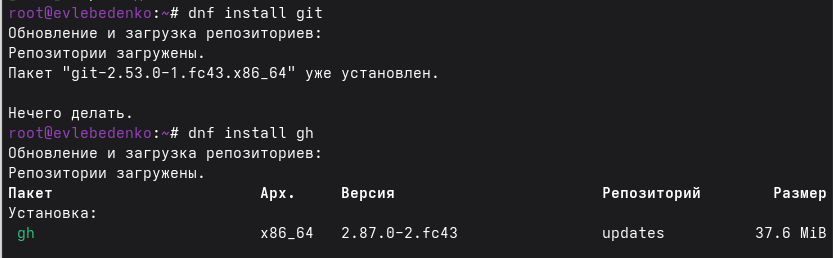

Установка git и gh

Зададаю имя и email владельца репозитория, настраиваю utf-8 в выводе сообщений git, зададаю имя начальной ветки, параметр autocrlf и safecrlf.

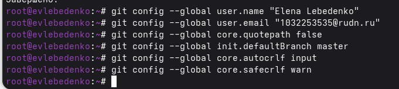

Создание ключей ssh

- по алгоритму rsa с ключём размером 4096 бит
- по алгоритму ed25519

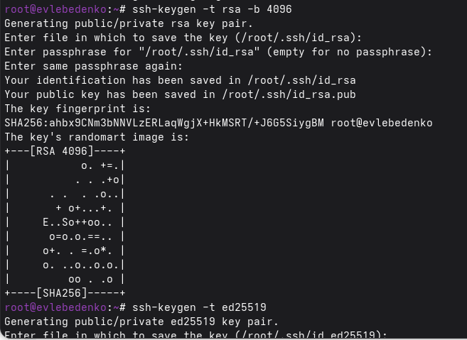

Создание ключей ssh

Генерирую ключ

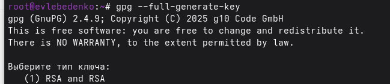

Создание ключей pgp

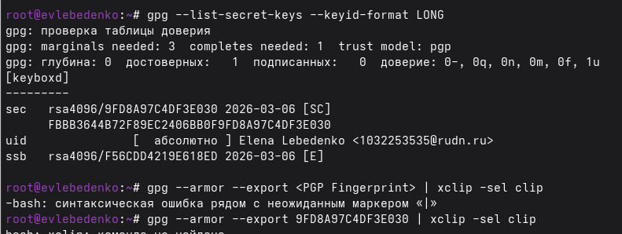

Добавление PGP ключа в GitHub

Используя введёный email, указываю Git применять его при подписи коммитов

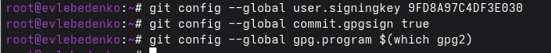

Настройка автоматических подписей коммитов git

Авторизуюсь

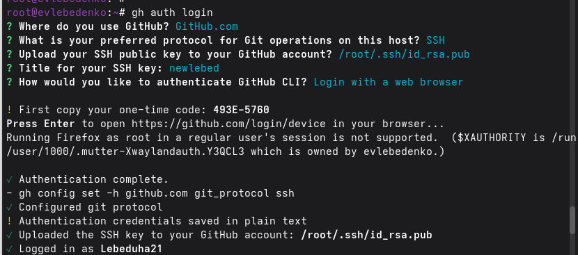

Настройка gh

Создаю шаблон рабочего пространства

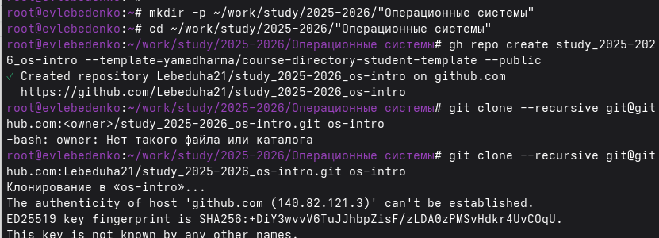

Сознание репозитори

Перехожу в каталог курса, удаляю лишние файлы, создаю необходимые каталоги

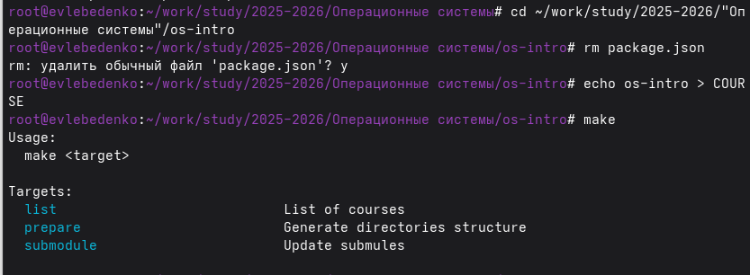

Сознание репозитори

Отправляю файлы на сервер

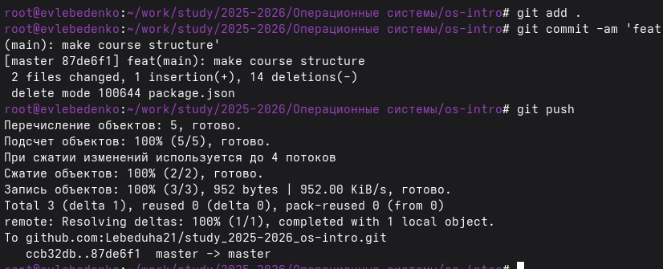

Сознание репозитори

# Выводы

В результате выполнения лабараторной работы я изучила идеологию и применение средств контроля версий, а также освоила умения по работе с git